# Association Rules

Anda diminta untuk membuat Sistem Rekomendasi menggunakan Association Rules untuk dataset yang ditemukan secara mandiri. Dataset yang digunakan harus memenuhi ketentuan berikut:

- Berisi informasi tingkat individu (berupa pengguna, produk, transaksi, dan lainnya) yang dapat digunakan untuk membangun sebuah sistem rekomendasi.
- Sekurang-kurangnya terdiri atas 1000 observasi (baris).
- Setiap peserta kelas praktikum PDM **wajib** menggunakan dataset yang berbeda. Jika terdapat 2 peserta dengan 1 dataset yang sama tetapi menggunakan item yang berbeda dalam pembuatan sistem rekomendasi, maka diizinkan.

# **Tugas Anda adalah sebagai berikut:**

- Temukan data yang relevan sesuai dengan ketentuan di atas, dengan menyertakan sumber (link) dan informasi umum dari data (konteks, penjelasan variabel, dan tujuan pembuatan sistem rekomendasi)
- Lakukan preprocessing dataset sesuai kebutuhan hingga transformasi data sesuai dengan format yang dibutuhkan pada masing-masing algoritma
- Frequent Itemset Mining: Gunakan algoritma FP-Growth dan Apriori untuk menemukan item-item yang sering muncul bersama dalam dataset.
  - Kode Algoritma Apriori
  - Berikan Penjelasan tentang hasilnya
  - Kode Algoritma FP-Growth
  - Berikan Penjelasan tentang hasilnya
  - Nilai minimum support yang digunakan bebas di atur oleh peserta.
- Gunakan itemset frekuensi yang ditemukan untuk menemukan aturan asosiasi antara item yang muncul bersama dalam dataset.
  - Kode Aturan Asosiasi
  - Urutkan nilai berdasarkan nilai confidence dan lift
  - Berikan Penjelasan tentang hasilnya

**Buatlah semua code dari awal seperti yang pernah dipelajari sebelumnya**

```python
import numpy as np
import pandas as pd
import seaborn as sns
import matplotlib.pyplot as plt
%matplotlib inline
import mlxtend as ml
# from scipy import sparse
from mlxtend.frequent_patterns import apriori
from mlxtend.frequent_patterns import association_rules
from mlxtend.preprocessing import TransactionEncoder
from mlxtend.frequent_patterns import fpgrowth
pd.set_option('display.max_columns', 500)
pd.set_option('display.width', 1000)
```

## 1 - Dataset

Dataset ini memiliki beberapa variabel diantaranya adalah:

`TransactionNo` : 6 digit kode unik yang membedakan setiap transaksi. Kode C mengartikan adanya cancellation. Hal ini terjadi karena adanya kehabisan stok

`Date` : tanggal transaksi setiap konsumen diberlakukan

`ProductNo` : 5-6 digit unik untuk mendefinisikan setiap produk yang dijual

`Price` : harga setiap produk yang dijual dalam satuan poundsterling (£)

`Quantity` : kuantitas tiap pembelian produk per transaksi, nilai negatif menandakan transaksi yang dibatalkan

`CustomerNo` : 5 digit yang mendefinisikan setiap konsumen

`Country` : negara konsumen berada

- Tujuan: Mencari frequent itemset atau barang yang sering dibeli bersamaan dalam satu kali transaksi oleh setiap konsumen. Membuat sebuah sistem rekomendasi untuk menciptakan terobosan-terobosan marketing baru melalui algoritma asosiasi. Melalui website, mungkin bisa meletakkan barang-barang yang sering dibeli pada halaman awal website dan membuatnya kelihatan mencolok agar konsumen bisa menjangkau nya dengan baik dan melakukan pembelian ulang. Selain itu, dengan website kita biasanya bisa melacak klik dan scroll para pengguna website. Setelah itu bisa dianalisis mana saja item-item yang jarang terjangkau oleh para konsumen.

```python
# Load Data
sns.set_style('whitegrid')
datasales = pd.read_csv('/Users/revaldyhazzadaniswara/Downloads/Sales Transaction v.4a.csv', index_col='TransactionNo')

# Menampilkan Data
datasales.head()
```

| TransactionNo | Date | ProductNo | ProductName | Price | Quantity | CustomerNo | Country |
| --- | --- | --- | --- | --- | --- | --- | --- |
| 581482 | 12/9/2019 | 22485 | Set Of 2 Wooden Market Crates | 21.47 | 12 | 17490.0 | United Kingdom |
| 581475 | 12/9/2019 | 22596 | Christmas Star Wish List Chalkboard | 10.65 | 36 | 13069.0 | United Kingdom |
| 581475 | 12/9/2019 | 23235 | Storage Tin Vintage Leaf | 11.53 | 12 | 13069.0 | United Kingdom |
| 581475 | 12/9/2019 | 23272 | Tree T-Light Holder Willie Winkie | 10.65 | 12 | 13069.0 | United Kingdom |
| 581475 | 12/9/2019 | 23239 | Set Of 4 Knick Knack Tins Poppies | 11.94 | 6 | 13069.0 | United Kingdom |

```python
# Melihat statistik deskriptif dari data
datasales.describe()
```

|  | Price | Quantity | CustomerNo |
| --- | --- | --- | --- |
| count | 536350.000000 | 536350.000000 | 536295.000000 |
| mean | 12.662182 | 9.919347 | 15227.893178 |
| std | 8.490450 | 216.662300 | 1716.582932 |
| min | 5.130000 | -80995.000000 | 12004.000000 |
| 25% | 10.990000 | 1.000000 | 13807.000000 |
| 50% | 11.940000 | 3.000000 | 15152.000000 |
| 75% | 14.090000 | 10.000000 | 16729.000000 |
| max | 660.620000 | 80995.000000 | 18287.000000 |

Terlihat pada quantity terdapat nilai negatif. Hal ini bermakna terdapat adanya cancellation atau pembatalan transaksi. Oleh karena itu, perlu dilakukan adanya preprocessing terlebih dahulu

```python
# Melihat tipe data serta atribut apa saja yang terdapat dalam data
datasales.info()
```

```
<class 'pandas.core.frame.DataFrame'>
Index: 536350 entries, 581482 to C536548
Data columns (total 7 columns):
 #   Column       Non-Null Count   Dtype
---  ------       --------------   -----
 0   Date         536350 non-null  object
 1   ProductNo    536350 non-null  object
 2   ProductName  536350 non-null  object
 3   Price        536350 non-null  float64
 4   Quantity     536350 non-null  int64
 5   CustomerNo   536295 non-null  float64
 6   Country      536350 non-null  object
dtypes: float64(2), int64(1), object(4)
memory usage: 32.7+ MB
```

## 2.1 - Exploration

```python
# Melihat ukuran dataset
datasales.shape
```

```
(536350, 7)
```

```python
# Melihat jumlah penjualan setiap produk
datasales['ProductName'].value_counts()
```

```
ProductName
Cream Hanging Heart T-Light Holder    2378
Regency Cakestand 3 Tier              2200
Jumbo Bag Red Retrospot               2159
Party Bunting                         1727
Lunch Bag Red Retrospot               1639
                                      ...
Cat With Sunglasses Blank Card           1
Letter "U" Bling Key Ring                1
Ocean Stripe Hammock                     1
Incense Bazaar Peach                     1
Porcelain Hanging Bell Small             1
Name: count, Length: 3768, dtype: int64
```

```python
# Melihat data kategorik unik yang ada pada setiap atribut

datasales.columns
for col in datasales.columns:
    if datasales[col].dtype == 'object':
        print(col, datasales[col].unique())
```

```
Date ['12/9/2019' '12/8/2019' '12/7/2019' '12/6/2019' '12/5/2019' '12/4/2019'
 '12/2/2019' '12/1/2019' '11/30/2019' '11/29/2019' '11/28/2019'
 '11/27/2019' '11/25/2019' '11/24/2019' '11/23/2019' '11/22/2019'
 '11/21/2019' '11/20/2019' '11/18/2019' '11/17/2019' '11/16/2019'
 '11/15/2019' '11/14/2019' '11/13/2019' '11/11/2019' '11/10/2019'
 '11/9/2019' '11/8/2019' '11/7/2019' '11/6/2019' '11/4/2019' '11/3/2019'
 '11/2/2019' '11/1/2019' '10/31/2019' '10/30/2019' '10/28/2019'
 '10/27/2019' '10/26/2019' '10/25/2019' '10/24/2019' '10/23/2019'
 '10/21/2019' '10/20/2019' '10/19/2019' '10/18/2019' '10/17/2019'
 '10/16/2019' '10/14/2019' '10/13/2019' '10/12/2019' '10/11/2019'
 '10/10/2019' '10/9/2019' '10/7/2019' '10/6/2019' '10/5/2019' '10/4/2019'
 '10/3/2019' '10/2/2019' '9/30/2019' '9/29/2019' '9/28/2019' '9/27/2019'
 '9/26/2019' '9/25/2019' '9/23/2019' '9/22/2019' '9/21/2019' '9/20/2019'
 '9/19/2019' '9/18/2019' '9/16/2019' '9/15/2019' '9/14/2019' '9/13/2019'
 '9/12/2019' '9/11/2019' '9/9/2019' '9/8/2019' '9/7/2019' '9/6/2019'
 '9/5/2019' '9/4/2019' '9/2/2019' '9/1/2019' '8/31/2019' '8/30/2019'
 '8/28/2019' '8/26/2019' '8/25/2019' '8/24/2019' '8/23/2019' '8/22/2019'
 '8/21/2019' '8/19/2019' '8/18/2019' '8/17/2019' '8/16/2019' '8/15/2019'
 '8/14/2019' '8/12/2019' '8/11/2019' '8/10/2019' '8/9/2019' '8/8/2019'
 '8/7/2019' '8/5/2019' '8/4/2019' '8/3/2019' '8/2/2019' '8/1/2019'
 '7/31/2019' '7/29/2019' '7/28/2019' '7/27/2019' '7/26/2019' '7/25/2019'
 '7/24/2019' '7/22/2019' '7/21/2019' '7/20/2019' '7/19/2019' '7/18/2019'
 '7/17/2019' '7/15/2019' '7/14/2019' '7/13/2019' '7/12/2019' '7/11/2019'
 '7/10/2019' '7/8/2019' '7/7/2019' '7/6/2019' '7/5/2019' '7/4/2019'
 '7/3/2019' '7/1/2019' '6/30/2019' '6/29/2019' '6/28/2019' '6/27/2019'
 '6/26/2019' '6/24/2019' '6/23/2019' '6/22/2019' '6/21/2019' '6/20/2019'
 '6/19/2019' '6/17/2019' '6/16/2019' '6/15/2019' '6/14/2019' '6/13/2019'
 '6/12/2019' '6/10/2019' '6/9/2019' '6/8/2019' '6/7/2019' '6/6/2019'
 '6/5/2019' '6/3/2019' '6/2/2019' '6/1/2019' '5/31/2019' '5/29/2019'
 '5/27/2019' '5/26/2019' '5/25/2019' '5/24/2019' '5/23/2019' '5/22/2019'
 '5/20/2019' '5/19/2019' '5/18/2019' '5/17/2019' '5/16/2019' '5/15/2019'
 '5/13/2019' '5/12/2019' '5/11/2019' '5/10/2019' '5/9/2019' '5/8/2019'
 '5/6/2019' '5/5/2019' '5/4/2019' '5/3/2019' '5/1/2019' '4/28/2019'
 '4/27/2019' '4/26/2019' '4/21/2019' '4/20/2019' '4/19/2019' '4/18/2019'
 '4/17/2019' '4/15/2019' '4/14/2019' '4/13/2019' '4/12/2019' '4/11/2019'
 '4/10/2019' '4/8/2019' '4/7/2019' '4/6/2019' '4/5/2019' '4/4/2019'
 '4/3/2019' '4/1/2019' '3/31/2019' '3/30/2019' '3/29/2019' '3/28/2019'
 '3/27/2019' '3/25/2019' '3/24/2019' '3/23/2019' '3/22/2019' '3/21/2019'
 '3/20/2019' '3/18/2019' '3/17/2019' '3/16/2019' '3/15/2019' '3/14/2019'
 '3/13/2019' '3/11/2019' '3/10/2019' '3/9/2019' '3/8/2019' '3/7/2019'
```

[output cut: 9 more lines]

```
 '12/22/2018' '12/21/2018' '12/20/2018' '12/19/2018' '12/17/2018'
 '12/16/2018' '12/15/2018' '12/14/2018' '12/13/2018' '12/12/2018'
 '12/10/2018' '12/9/2018' '12/8/2018' '12/7/2018' '12/6/2018' '12/5/2018'
 '12/3/2018' '12/2/2018' '12/1/2018']
ProductNo ['22485' '22596' '23235' ... '84854' '82615' '20957']
ProductName ['Set Of 2 Wooden Market Crates' 'Christmas Star Wish List Chalkboard'
 'Storage Tin Vintage Leaf' ... 'Girly Pink Tool Set'
 'Pink Marshmallow Scarf Knitting Kit' 'Porcelain Hanging Bell Small']
Country ['United Kingdom' 'Norway' 'Belgium' 'Germany' 'France' 'Austria'
 'Netherlands' 'EIRE' 'USA' 'Channel Islands' 'Iceland' 'Portugal' 'Spain'
 'Finland' 'Italy' 'Greece' 'Japan' 'Sweden' 'Denmark' 'Cyprus' 'Malta'
 'Switzerland' 'Australia' 'Czech Republic' 'Poland' 'Hong Kong'
 'Singapore' 'RSA' 'Israel' 'Unspecified' 'United Arab Emirates' 'Canada'
 'European Community' 'Bahrain' 'Brazil' 'Saudi Arabia' 'Lebanon'
 'Lithuania']
```

```python
# Melihat data yang kosong
datasales.isna().sum()
```

```
Date            0
ProductNo       0
ProductName     0
Price           0
Quantity        0
CustomerNo     55
Country         0
dtype: int64
```

Melihat kolom yang kosong hanya CustomerNo dan tidak terlalu berpengaruh pada transaksi, maka tidak akan dilakukan penghapusan data yang kosong. Hal ini bisa saja terjadi karena konsumen belum terdaftar pada website.

## Preprocessing

```python
# Melihat persentase data yang kosong

pd.DataFrame({'Jumlah NA': datasales.isna().sum(), 'Persentase': (datasales.isna().sum()/len(datasales)*100)})
```

|  | Jumlah NA | Persentase |
| --- | --- | --- |
| Date | 0 | 0.000000 |
| ProductNo | 0 | 0.000000 |
| ProductName | 0 | 0.000000 |
| Price | 0 | 0.000000 |
| Quantity | 0 | 0.000000 |
| CustomerNo | 55 | 0.010254 |
| Country | 0 | 0.000000 |

```python
# Membuat atribut baru yaitu Sales yang mengartikan jumlah uang yang dikeluarkan oleh konsumen berdasarkan barang dan kuantitas yang ia beli
datasales['Sales'] = datasales['Price']*datasales['Quantity']
```

```python
# Menghapus data yang termasuk pada transaksi Cancellation dengan memilih data Quantity yang lebih dari sama dengan 0
datasales = datasales[datasales['Quantity'] >= 0]
```

Di awal penjelasan data, sudah dijelaskan jika terdapat beberapa transaksi yang dibatalkan karena kehabisan stok. Hal ini dapat dilihat melalui nomor transaksi yang mengandung C atau dengan melihat kuantitas pembelian yang bernilai negatif

```python
datasales.describe()
```

|  | Price | Quantity | CustomerNo | Sales |
| --- | --- | --- | --- | --- |
| count | 527765.000000 | 527765.000000 | 527764.000000 | 5.277650e+05 |
| mean | 12.629636 | 10.594674 | 15231.626733 | 1.193068e+02 |
| std | 7.933217 | 156.786646 | 1716.522182 | 1.851191e+03 |
| min | 5.130000 | 1.000000 | 12004.000000 | 5.130000e+00 |
| 25% | 10.990000 | 1.000000 | 13813.000000 | 1.717000e+01 |
| 50% | 11.940000 | 3.000000 | 15159.000000 | 4.383000e+01 |
| 75% | 14.090000 | 11.000000 | 16729.000000 | 1.194000e+02 |
| max | 660.620000 | 80995.000000 | 18287.000000 | 1.002718e+06 |

Dapat dilihat pada kolom quantity sudah tidak ada data yang bernilai negatif. Hal ini berarti sudah tidak ada transaksi yang dibatalkan. Selanjutnya bisa dilakukan analisis lebih lanjut.

```python
# Mengelompokkan dan melihat produk-produk berdasarkan penjualannya.
datasales1 = datasales.drop(['Date', 'ProductNo', 'Price', 'Quantity', 'CustomerNo', 'Country'], axis=1).groupby('ProductName').sum()
datasales1
```

| ProductName | Sales |
| --- | --- |
| 10 Colour Spaceboy Pen | 71972.51 |
| 12 Coloured Party Balloons | 22933.78 |
| 12 Daisy Pegs In Wood Box | 4192.68 |
| 12 Egg House Painted Wood | 3787.54 |
| 12 Hanging Eggs Hand Painted | 366.47 |
| ... | ... |
| Zinc T-Light Holder Stars Small | 55344.28 |
| Zinc Top 2 Door Wooden Shelf | 410.04 |
| Zinc Willie Winkie Candle Stick | 31512.83 |
| Zinc Wire Kitchen Organiser | 414.20 |
| Zinc Wire Sweetheart Letter Tray | 1039.38 |

3753 rows × 1 columns

```python
# Melihat dan mengurutkan berdasarkan penjualan tertinggi
datasales1.sort_values(by=['Sales'],ascending=False).head(30)
```

| ProductName | Sales |
| --- | --- |
| Paper Craft Little Birdie | 1002718.10 |
| Medium Ceramic Top Storage Jar | 881990.18 |
| Popcorn Holder | 587433.94 |
| World War 2 Gliders Asstd Designs | 569735.39 |
| Cream Hanging Heart T-Light Holder | 484592.69 |
| Assorted Colour Bird Ornament | 421318.74 |
| Pack Of 72 Retrospot Cake Cases | 391485.03 |
| Rabbit Night Light | 329029.89 |
| Regency Cakestand 3 Tier | 307483.85 |
| Jumbo Bag Red Retrospot | 297205.04 |
| Mini Paint Set Vintage | 287001.66 |
| Party Bunting | 286596.09 |
| Victorian Glass Hanging T-Light | 274287.34 |
| Pack Of 12 London Tissues | 271027.14 |
| Pack Of 60 Pink Paisley Cake Cases | 264629.40 |
| Assorted Colours Silk Fan | 261513.88 |
| Red Harmonica In Box | 246003.47 |
| Brocade Ring Purse | 239794.00 |
| Paper Chain Kit 50'S Christmas | 234414.31 |
| Antique Silver T-Light Glass | 216858.23 |
| Heart Of Wicker Small | 210920.39 |
| Charlotte Bag Suki Design | 205303.99 |
| Red Retrospot Charlotte Bag | 195144.64 |
| 60 Teatime Fairy Cake Cases | 194570.86 |
| Jam Making Set Printed | 186081.61 |
| Grow A Flytrap Or Sunflower In Tin | 182585.03 |
| Colour Glass T-Light Holder Hanging | 176898.36 |
| Spaceboy Lunch Box | 167810.62 |
| Jumbo Storage Bag Suki | 167595.75 |
| 60 Cake Cases Vintage Christmas | 165752.19 |

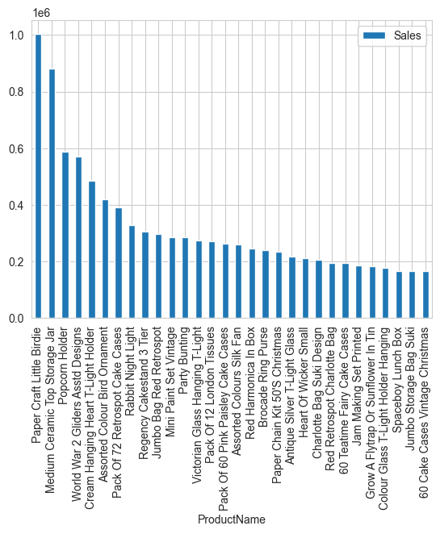

```python
# Melakukan visualisasi berdasarkan penjualan tertinggi ke terendah
datasales1.sort_values(by=['Sales'],ascending=False).head(30).plot(kind='bar')
```

## 3 - Frequent Itemset Mining

## Transformation

```python
#Melakukan transformasi Hot Encoded untuk datasales
datasalesHotEncoded = datasales.pivot_table(index = 'TransactionNo', columns='ProductName', values='Sales')
datasalesHotEncoded
```

| ProductName TransactionNo | 10 Colour Spaceboy Pen | 12 Coloured Party Balloons | 12 Daisy Pegs In Wood Box | 12 Egg House Painted Wood | 12 Hanging Eggs Hand Painted | 12 Ivory Rose Peg Place Settings | 12 Message Cards With Envelopes | 12 Pencil Small Tube Woodland | 12 Pencils Small Tube Red Retrospot | 12 Pencils Small Tube Skull | 12 Pencils Tall Tube Posy | 12 Pencils Tall Tube Red Retrospot | 12 Pencils Tall Tube Skulls | 12 Pencils Tall Tube Woodland | 12 Pink Hen+Chicks In Basket | 12 Pink Rose Peg Place Settings | 12 Red Rose Peg Place Settings | 15 Pink Fluffy Chicks In Box | 15cm Christmas Glass Ball 20 Lights | 16 Piece Cutlery Set Pantry Design | 18pc Wooden Cutlery Set Disposable | 2 Daisies Hair Comb | 2 Picture Book Eggs Easter Bunny | 2 Picture Book Eggs Easter Chicks | 2 Picture Book Eggs Easter Ducks | 20 Dolly Pegs Retrospot | 200 Bendy Skull Straws | 200 Red + White Bendy Straws | 3 Birds Canvas Screen | … |
| --- | --- | --- | --- | --- | --- | --- | --- | --- | --- | --- | --- | --- | --- | --- | --- | --- | --- | --- | --- | --- | --- | --- | --- | --- | --- | --- | --- | --- | --- | --- |
| 536365 | NaN | NaN | NaN | NaN | NaN | NaN | NaN | NaN | NaN | NaN | NaN | NaN | NaN | NaN | NaN | NaN | NaN | NaN | NaN | NaN | NaN | NaN | NaN | NaN | NaN | NaN | NaN | NaN | NaN | … |
| 536366 | NaN | NaN | NaN | NaN | NaN | NaN | NaN | NaN | NaN | NaN | NaN | NaN | NaN | NaN | NaN | NaN | NaN | NaN | NaN | NaN | NaN | NaN | NaN | NaN | NaN | NaN | NaN | NaN | NaN | … |
| 536367 | NaN | NaN | NaN | NaN | NaN | NaN | NaN | NaN | NaN | NaN | NaN | NaN | NaN | NaN | NaN | NaN | NaN | NaN | NaN | NaN | NaN | NaN | NaN | NaN | NaN | NaN | NaN | NaN | NaN | … |
| 536368 | NaN | NaN | NaN | NaN | NaN | NaN | NaN | NaN | NaN | NaN | NaN | NaN | NaN | NaN | NaN | NaN | NaN | NaN | NaN | NaN | NaN | NaN | NaN | NaN | NaN | NaN | NaN | NaN | NaN | … |
| 536369 | NaN | NaN | NaN | NaN | NaN | NaN | NaN | NaN | NaN | NaN | NaN | NaN | NaN | NaN | NaN | NaN | NaN | NaN | NaN | NaN | NaN | NaN | NaN | NaN | NaN | NaN | NaN | NaN | NaN | … |
| ... | ... | ... | ... | ... | ... | ... | ... | ... | ... | ... | ... | ... | ... | ... | ... | ... | ... | ... | ... | ... | ... | ... | ... | ... | ... | ... | ... | ... | ... | … |
| 581583 | NaN | NaN | NaN | NaN | NaN | NaN | NaN | NaN | NaN | NaN | NaN | NaN | NaN | NaN | NaN | NaN | NaN | NaN | NaN | NaN | NaN | NaN | NaN | NaN | NaN | NaN | NaN | NaN | NaN | … |
| 581584 | NaN | NaN | NaN | NaN | NaN | NaN | NaN | NaN | NaN | NaN | NaN | NaN | NaN | NaN | NaN | NaN | NaN | NaN | NaN | NaN | NaN | NaN | NaN | NaN | NaN | NaN | NaN | NaN | NaN | … |
| 581585 | NaN | NaN | NaN | NaN | NaN | NaN | NaN | NaN | NaN | NaN | NaN | NaN | NaN | NaN | NaN | NaN | NaN | NaN | NaN | NaN | NaN | NaN | NaN | NaN | NaN | NaN | NaN | NaN | NaN | … |
| 581586 | NaN | NaN | NaN | NaN | NaN | NaN | NaN | NaN | NaN | NaN | NaN | NaN | NaN | NaN | NaN | NaN | NaN | NaN | NaN | NaN | NaN | NaN | NaN | NaN | NaN | NaN | NaN | NaN | NaN | … |
| 581587 | NaN | NaN | NaN | NaN | NaN | NaN | NaN | NaN | NaN | NaN | NaN | NaN | NaN | NaN | NaN | NaN | NaN | NaN | NaN | NaN | NaN | NaN | NaN | NaN | NaN | NaN | NaN | NaN | NaN | … |

19790 rows × 3753 columns

```python
# Melihat perubahan bentuk dari datasales menjadi datasalesHotEncoded
print(datasales.shape)
print(datasalesHotEncoded.shape)
```

```
(527765, 8)
(19790, 3753)
```

Terjadi perubahan dimensi pada baris dan kolom setelah dilakukan transformasi.

```python
# Mengisi data kosong menggunakan angka 0
datasalesHotEncoded = datasales.pivot_table(index = 'TransactionNo', columns='ProductName', values='Sales').fillna(0)
datasalesHotEncoded
```

| ProductName TransactionNo | 10 Colour Spaceboy Pen | 12 Coloured Party Balloons | 12 Daisy Pegs In Wood Box | 12 Egg House Painted Wood | 12 Hanging Eggs Hand Painted | 12 Ivory Rose Peg Place Settings | 12 Message Cards With Envelopes | 12 Pencil Small Tube Woodland | 12 Pencils Small Tube Red Retrospot | 12 Pencils Small Tube Skull | 12 Pencils Tall Tube Posy | 12 Pencils Tall Tube Red Retrospot | 12 Pencils Tall Tube Skulls | 12 Pencils Tall Tube Woodland | 12 Pink Hen+Chicks In Basket | 12 Pink Rose Peg Place Settings | 12 Red Rose Peg Place Settings | 15 Pink Fluffy Chicks In Box | 15cm Christmas Glass Ball 20 Lights | 16 Piece Cutlery Set Pantry Design | 18pc Wooden Cutlery Set Disposable | 2 Daisies Hair Comb | 2 Picture Book Eggs Easter Bunny | 2 Picture Book Eggs Easter Chicks | 2 Picture Book Eggs Easter Ducks | 20 Dolly Pegs Retrospot | 200 Bendy Skull Straws | 200 Red + White Bendy Straws | 3 Birds Canvas Screen | … |
| --- | --- | --- | --- | --- | --- | --- | --- | --- | --- | --- | --- | --- | --- | --- | --- | --- | --- | --- | --- | --- | --- | --- | --- | --- | --- | --- | --- | --- | --- | --- |
| 536365 | 0.0 | 0.0 | 0.0 | 0.0 | 0.0 | 0.0 | 0.0 | 0.0 | 0.0 | 0.0 | 0.0 | 0.0 | 0.0 | 0.0 | 0.0 | 0.0 | 0.0 | 0.0 | 0.0 | 0.0 | 0.0 | 0.0 | 0.0 | 0.0 | 0.0 | 0.0 | 0.0 | 0.0 | 0.0 | … |
| 536366 | 0.0 | 0.0 | 0.0 | 0.0 | 0.0 | 0.0 | 0.0 | 0.0 | 0.0 | 0.0 | 0.0 | 0.0 | 0.0 | 0.0 | 0.0 | 0.0 | 0.0 | 0.0 | 0.0 | 0.0 | 0.0 | 0.0 | 0.0 | 0.0 | 0.0 | 0.0 | 0.0 | 0.0 | 0.0 | … |
| 536367 | 0.0 | 0.0 | 0.0 | 0.0 | 0.0 | 0.0 | 0.0 | 0.0 | 0.0 | 0.0 | 0.0 | 0.0 | 0.0 | 0.0 | 0.0 | 0.0 | 0.0 | 0.0 | 0.0 | 0.0 | 0.0 | 0.0 | 0.0 | 0.0 | 0.0 | 0.0 | 0.0 | 0.0 | 0.0 | … |
| 536368 | 0.0 | 0.0 | 0.0 | 0.0 | 0.0 | 0.0 | 0.0 | 0.0 | 0.0 | 0.0 | 0.0 | 0.0 | 0.0 | 0.0 | 0.0 | 0.0 | 0.0 | 0.0 | 0.0 | 0.0 | 0.0 | 0.0 | 0.0 | 0.0 | 0.0 | 0.0 | 0.0 | 0.0 | 0.0 | … |
| 536369 | 0.0 | 0.0 | 0.0 | 0.0 | 0.0 | 0.0 | 0.0 | 0.0 | 0.0 | 0.0 | 0.0 | 0.0 | 0.0 | 0.0 | 0.0 | 0.0 | 0.0 | 0.0 | 0.0 | 0.0 | 0.0 | 0.0 | 0.0 | 0.0 | 0.0 | 0.0 | 0.0 | 0.0 | 0.0 | … |
| ... | ... | ... | ... | ... | ... | ... | ... | ... | ... | ... | ... | ... | ... | ... | ... | ... | ... | ... | ... | ... | ... | ... | ... | ... | ... | ... | ... | ... | ... | … |
| 581583 | 0.0 | 0.0 | 0.0 | 0.0 | 0.0 | 0.0 | 0.0 | 0.0 | 0.0 | 0.0 | 0.0 | 0.0 | 0.0 | 0.0 | 0.0 | 0.0 | 0.0 | 0.0 | 0.0 | 0.0 | 0.0 | 0.0 | 0.0 | 0.0 | 0.0 | 0.0 | 0.0 | 0.0 | 0.0 | … |
| 581584 | 0.0 | 0.0 | 0.0 | 0.0 | 0.0 | 0.0 | 0.0 | 0.0 | 0.0 | 0.0 | 0.0 | 0.0 | 0.0 | 0.0 | 0.0 | 0.0 | 0.0 | 0.0 | 0.0 | 0.0 | 0.0 | 0.0 | 0.0 | 0.0 | 0.0 | 0.0 | 0.0 | 0.0 | 0.0 | … |
| 581585 | 0.0 | 0.0 | 0.0 | 0.0 | 0.0 | 0.0 | 0.0 | 0.0 | 0.0 | 0.0 | 0.0 | 0.0 | 0.0 | 0.0 | 0.0 | 0.0 | 0.0 | 0.0 | 0.0 | 0.0 | 0.0 | 0.0 | 0.0 | 0.0 | 0.0 | 0.0 | 0.0 | 0.0 | 0.0 | … |
| 581586 | 0.0 | 0.0 | 0.0 | 0.0 | 0.0 | 0.0 | 0.0 | 0.0 | 0.0 | 0.0 | 0.0 | 0.0 | 0.0 | 0.0 | 0.0 | 0.0 | 0.0 | 0.0 | 0.0 | 0.0 | 0.0 | 0.0 | 0.0 | 0.0 | 0.0 | 0.0 | 0.0 | 0.0 | 0.0 | … |
| 581587 | 0.0 | 0.0 | 0.0 | 0.0 | 0.0 | 0.0 | 0.0 | 0.0 | 0.0 | 0.0 | 0.0 | 0.0 | 0.0 | 0.0 | 0.0 | 0.0 | 0.0 | 0.0 | 0.0 | 0.0 | 0.0 | 0.0 | 0.0 | 0.0 | 0.0 | 0.0 | 0.0 | 0.0 | 0.0 | … |

19790 rows × 3753 columns

```python
# Mengubah data yang berisi sebuah nilai menjadi angka 1
datasalesHotEncoded[datasalesHotEncoded>0] = 1
datasalesHotEncoded
```

| ProductName TransactionNo | 10 Colour Spaceboy Pen | 12 Coloured Party Balloons | 12 Daisy Pegs In Wood Box | 12 Egg House Painted Wood | 12 Hanging Eggs Hand Painted | 12 Ivory Rose Peg Place Settings | 12 Message Cards With Envelopes | 12 Pencil Small Tube Woodland | 12 Pencils Small Tube Red Retrospot | 12 Pencils Small Tube Skull | 12 Pencils Tall Tube Posy | 12 Pencils Tall Tube Red Retrospot | 12 Pencils Tall Tube Skulls | 12 Pencils Tall Tube Woodland | 12 Pink Hen+Chicks In Basket | 12 Pink Rose Peg Place Settings | 12 Red Rose Peg Place Settings | 15 Pink Fluffy Chicks In Box | 15cm Christmas Glass Ball 20 Lights | 16 Piece Cutlery Set Pantry Design | 18pc Wooden Cutlery Set Disposable | 2 Daisies Hair Comb | 2 Picture Book Eggs Easter Bunny | 2 Picture Book Eggs Easter Chicks | 2 Picture Book Eggs Easter Ducks | 20 Dolly Pegs Retrospot | 200 Bendy Skull Straws | 200 Red + White Bendy Straws | 3 Birds Canvas Screen | … |
| --- | --- | --- | --- | --- | --- | --- | --- | --- | --- | --- | --- | --- | --- | --- | --- | --- | --- | --- | --- | --- | --- | --- | --- | --- | --- | --- | --- | --- | --- | --- |
| 536365 | 0.0 | 0.0 | 0.0 | 0.0 | 0.0 | 0.0 | 0.0 | 0.0 | 0.0 | 0.0 | 0.0 | 0.0 | 0.0 | 0.0 | 0.0 | 0.0 | 0.0 | 0.0 | 0.0 | 0.0 | 0.0 | 0.0 | 0.0 | 0.0 | 0.0 | 0.0 | 0.0 | 0.0 | 0.0 | … |
| 536366 | 0.0 | 0.0 | 0.0 | 0.0 | 0.0 | 0.0 | 0.0 | 0.0 | 0.0 | 0.0 | 0.0 | 0.0 | 0.0 | 0.0 | 0.0 | 0.0 | 0.0 | 0.0 | 0.0 | 0.0 | 0.0 | 0.0 | 0.0 | 0.0 | 0.0 | 0.0 | 0.0 | 0.0 | 0.0 | … |
| 536367 | 0.0 | 0.0 | 0.0 | 0.0 | 0.0 | 0.0 | 0.0 | 0.0 | 0.0 | 0.0 | 0.0 | 0.0 | 0.0 | 0.0 | 0.0 | 0.0 | 0.0 | 0.0 | 0.0 | 0.0 | 0.0 | 0.0 | 0.0 | 0.0 | 0.0 | 0.0 | 0.0 | 0.0 | 0.0 | … |
| 536368 | 0.0 | 0.0 | 0.0 | 0.0 | 0.0 | 0.0 | 0.0 | 0.0 | 0.0 | 0.0 | 0.0 | 0.0 | 0.0 | 0.0 | 0.0 | 0.0 | 0.0 | 0.0 | 0.0 | 0.0 | 0.0 | 0.0 | 0.0 | 0.0 | 0.0 | 0.0 | 0.0 | 0.0 | 0.0 | … |
| 536369 | 0.0 | 0.0 | 0.0 | 0.0 | 0.0 | 0.0 | 0.0 | 0.0 | 0.0 | 0.0 | 0.0 | 0.0 | 0.0 | 0.0 | 0.0 | 0.0 | 0.0 | 0.0 | 0.0 | 0.0 | 0.0 | 0.0 | 0.0 | 0.0 | 0.0 | 0.0 | 0.0 | 0.0 | 0.0 | … |
| ... | ... | ... | ... | ... | ... | ... | ... | ... | ... | ... | ... | ... | ... | ... | ... | ... | ... | ... | ... | ... | ... | ... | ... | ... | ... | ... | ... | ... | ... | … |
| 581583 | 0.0 | 0.0 | 0.0 | 0.0 | 0.0 | 0.0 | 0.0 | 0.0 | 0.0 | 0.0 | 0.0 | 0.0 | 0.0 | 0.0 | 0.0 | 0.0 | 0.0 | 0.0 | 0.0 | 0.0 | 0.0 | 0.0 | 0.0 | 0.0 | 0.0 | 0.0 | 0.0 | 0.0 | 0.0 | … |
| 581584 | 0.0 | 0.0 | 0.0 | 0.0 | 0.0 | 0.0 | 0.0 | 0.0 | 0.0 | 0.0 | 0.0 | 0.0 | 0.0 | 0.0 | 0.0 | 0.0 | 0.0 | 0.0 | 0.0 | 0.0 | 0.0 | 0.0 | 0.0 | 0.0 | 0.0 | 0.0 | 0.0 | 0.0 | 0.0 | … |
| 581585 | 0.0 | 0.0 | 0.0 | 0.0 | 0.0 | 0.0 | 0.0 | 0.0 | 0.0 | 0.0 | 0.0 | 0.0 | 0.0 | 0.0 | 0.0 | 0.0 | 0.0 | 0.0 | 0.0 | 0.0 | 0.0 | 0.0 | 0.0 | 0.0 | 0.0 | 0.0 | 0.0 | 0.0 | 0.0 | … |
| 581586 | 0.0 | 0.0 | 0.0 | 0.0 | 0.0 | 0.0 | 0.0 | 0.0 | 0.0 | 0.0 | 0.0 | 0.0 | 0.0 | 0.0 | 0.0 | 0.0 | 0.0 | 0.0 | 0.0 | 0.0 | 0.0 | 0.0 | 0.0 | 0.0 | 0.0 | 0.0 | 0.0 | 0.0 | 0.0 | … |
| 581587 | 0.0 | 0.0 | 0.0 | 0.0 | 0.0 | 0.0 | 0.0 | 0.0 | 0.0 | 0.0 | 0.0 | 0.0 | 0.0 | 0.0 | 0.0 | 0.0 | 0.0 | 0.0 | 0.0 | 0.0 | 0.0 | 0.0 | 0.0 | 0.0 | 0.0 | 0.0 | 0.0 | 0.0 | 0.0 | … |

19790 rows × 3753 columns

### **Apriori**

```python
# Melakukan algoritma apriori dan melihat frequent itemset dari dataset ini, menggunakan minimal support 3% atau 0.03
datasales2 = apriori(datasalesHotEncoded, min_support =0.03, use_colnames=True)
datasales2
```

|  | support | itemsets |
| --- | --- | --- |
| 0 | 0.030571 | (3 Drawer Antique White Wood Cabinet) |
| 1 | 0.048257 | (6 Ribbons Rustic Charm) |
| 2 | 0.031278 | (60 Cake Cases Vintage Christmas) |
| 3 | 0.041890 | (60 Teatime Fairy Cake Cases) |
| 4 | 0.031076 | (72 Sweetheart Fairy Cake Cases) |
| ... | ... | ... |
| 138 | 0.036584 | (Jumbo Bag Red Retrospot, Jumbo Storage Bag Suki) |
| 139 | 0.032441 | (Lunch Bag Black Skull, Lunch Bag Red Retrospot) |
| 140 | 0.030622 | (Lunch Bag Pink Polkadot, Lunch Bag Red Retros... |
| 141 | 0.033148 | (Lunch Bag Suki Design, Lunch Bag Red Retrospot) |
| 142 | 0.030268 | (Pink Regency Teacup And Saucer, Roses Regency... |

143 rows × 2 columns

```python
datasales2.sort_values(by=['support'], ascending=False)
```

|  | support | itemsets |
| --- | --- | --- |
| 20 | 0.114654 | (Cream Hanging Heart T-Light Holder) |
| 55 | 0.105710 | (Jumbo Bag Red Retrospot) |
| 103 | 0.100505 | (Regency Cakestand 3 Tier) |
| 89 | 0.085245 | (Party Bunting) |
| 72 | 0.079181 | (Lunch Bag Red Retrospot) |
| ... | ... | ... |
| 12 | 0.030470 | (Blue Harmonica In Box) |
| 81 | 0.030369 | (Pack Of 60 Dinosaur Cake Cases) |
| 23 | 0.030318 | (Doormat New England) |
| 142 | 0.030268 | (Pink Regency Teacup And Saucer, Roses Regency... |
| 52 | 0.030066 | (Jumbo Bag Pears) |

143 rows × 2 columns

#### **Penjelasan**

Setelah melakukan algoritma apriori, maka didapat 143 frequent itemsets dengan support masing-masing. Interpretasi nya adalah ada (support*100%) dari semua transaksi yang membeli (itemset). Support tertinggi didapatkan oleh Cream Hanging Heart T-Light Holder. Hal ini selaras dengan value_counts di awal kode yang terbanyak yaitu (Cream Hanging Heart T-Light Holder). Hal ini menandakan semakin sering muncul maka support nya semakin tinggi.

### Fpgrowth

```python
# Melakukan algortima asosiasi berupa FP Growth
fp_growth =fpgrowth(datasalesHotEncoded, min_support=0.03, use_colnames=True)
fp_growth
```

|  | support | itemsets |
| --- | --- | --- |
| 0 | 0.114654 | (Cream Hanging Heart T-Light Holder) |
| 1 | 0.073623 | (Assorted Colour Bird Ornament) |
| 2 | 0.039313 | (Home Building Block Word) |
| 3 | 0.031784 | (Love Building Block Word) |
| 4 | 0.030318 | (Doormat New England) |
| ... | ... | ... |
| 138 | 0.033148 | (Lunch Bag Suki Design, Lunch Bag Red Retrospot) |
| 139 | 0.032441 | (Lunch Bag Black Skull, Lunch Bag Red Retrospot) |
| 140 | 0.038807 | (Green Regency Teacup And Saucer, Roses Regenc... |
| 141 | 0.031986 | (Green Regency Teacup And Saucer, Pink Regency... |
| 142 | 0.030268 | (Pink Regency Teacup And Saucer, Roses Regency... |

143 rows × 2 columns

```python
fp_growth.sort_values(by=['support'], ascending=False)
```

|  | support | itemsets |
| --- | --- | --- |
| 0 | 0.114654 | (Cream Hanging Heart T-Light Holder) |
| 43 | 0.105710 | (Jumbo Bag Red Retrospot) |
| 85 | 0.100505 | (Regency Cakestand 3 Tier) |
| 107 | 0.085245 | (Party Bunting) |
| 20 | 0.079181 | (Lunch Bag Red Retrospot) |
| ... | ... | ... |
| 50 | 0.030470 | (Hanging Heart Zinc T-Light Holder) |
| 29 | 0.030369 | (Pack Of 60 Dinosaur Cake Cases) |
| 4 | 0.030318 | (Doormat New England) |
| 142 | 0.030268 | (Pink Regency Teacup And Saucer, Roses Regency... |
| 122 | 0.030066 | (Jumbo Bag Pears) |

143 rows × 2 columns

Sama halnya dengan apriori, kita dapat melihat frequent itemset atau itemset yang sering muncul dalam dataset. Hal ini bisa dilihat dari value_counts pada kode di awal, didapatkan jika (Cream Hanging Heart T-Light Holder) paling sering muncul dan memiliki support tertinggi. Untuk jumlah frequent itemset sama saja dengan apriori yaitu 143 frequent itemset.

## 4 - Association Rule

Bagian ini tidak harus menyertakan tampilan visualisasi

```python
# Melakukan algoritma association rules apriori dengan metric confidence
rulesapriori = association_rules(datasales2, metric ='confidence', min_threshold=0.5)
rulesapriori
```

|  | antecedents | consequents | antecedent support | consequent support | support | confidence | lift | leverage | conviction | zhangs_metric |
| --- | --- | --- | --- | --- | --- | --- | --- | --- | --- | --- |
| 0 | (Alarm Clock Bakelike Red) | (Alarm Clock Bakelike Green) | 0.053108 | 0.049570 | 0.032340 | 0.608944 | 12.284403 | 0.029707 | 2.430417 | 0.970117 |
| 1 | (Alarm Clock Bakelike Green) | (Alarm Clock Bakelike Red) | 0.049570 | 0.053108 | 0.032340 | 0.652396 | 12.284403 | 0.029707 | 2.724051 | 0.966506 |
| 2 | (Green Regency Teacup And Saucer) | (Pink Regency Teacup And Saucer) | 0.051289 | 0.038706 | 0.031986 | 0.623645 | 16.112194 | 0.030001 | 2.554222 | 0.988641 |
| 3 | (Pink Regency Teacup And Saucer) | (Green Regency Teacup And Saucer) | 0.038706 | 0.051289 | 0.031986 | 0.826371 | 16.112194 | 0.030001 | 5.464007 | 0.975701 |
| 4 | (Green Regency Teacup And Saucer) | (Roses Regency Teacup And Saucer) | 0.051289 | 0.053866 | 0.038807 | 0.756650 | 14.047006 | 0.036045 | 3.887961 | 0.979023 |
| 5 | (Roses Regency Teacup And Saucer) | (Green Regency Teacup And Saucer) | 0.053866 | 0.051289 | 0.038807 | 0.720450 | 14.047006 | 0.036045 | 3.393713 | 0.981690 |
| 6 | (Jumbo Bag Pink Polkadot) | (Jumbo Bag Red Retrospot) | 0.061546 | 0.105710 | 0.041688 | 0.677340 | 6.407532 | 0.035182 | 2.771616 | 0.899281 |
| 7 | (Jumbo Shopper Vintage Red Paisley) | (Jumbo Bag Red Retrospot) | 0.059424 | 0.105710 | 0.034361 | 0.578231 | 5.469980 | 0.028079 | 2.120333 | 0.868812 |
| 8 | (Jumbo Storage Bag Suki) | (Jumbo Bag Red Retrospot) | 0.059828 | 0.105710 | 0.036584 | 0.611486 | 5.784569 | 0.030260 | 2.301825 | 0.879761 |
| 9 | (Lunch Bag Black Skull) | (Lunch Bag Red Retrospot) | 0.064376 | 0.079181 | 0.032441 | 0.503925 | 6.364179 | 0.027343 | 1.856207 | 0.900865 |
| 10 | (Lunch Bag Pink Polkadot) | (Lunch Bag Red Retrospot) | 0.055078 | 0.079181 | 0.030622 | 0.555963 | 7.021387 | 0.026260 | 2.073744 | 0.907565 |
| 11 | (Lunch Bag Suki Design) | (Lunch Bag Red Retrospot) | 0.064982 | 0.079181 | 0.033148 | 0.510109 | 6.442281 | 0.028003 | 1.879639 | 0.903486 |
| 12 | (Pink Regency Teacup And Saucer) | (Roses Regency Teacup And Saucer) | 0.038706 | 0.053866 | 0.030268 | 0.781984 | 14.517326 | 0.028183 | 4.339754 | 0.968608 |
| 13 | (Roses Regency Teacup And Saucer) | (Pink Regency Teacup And Saucer) | 0.053866 | 0.038706 | 0.030268 | 0.561914 | 14.517326 | 0.028183 | 2.194302 | 0.984127 |

```python
# Melakukan algoritma association rules fp-growth dengan metric confidence
rules1fp = association_rules(fp_growth, metric ='confidence', min_threshold=0.5)
rules1fp
```

|  | antecedents | consequents | antecedent support | consequent support | support | confidence | lift | leverage | conviction | zhangs_metric |
| --- | --- | --- | --- | --- | --- | --- | --- | --- | --- | --- |
| 0 | (Alarm Clock Bakelike Red) | (Alarm Clock Bakelike Green) | 0.053108 | 0.049570 | 0.032340 | 0.608944 | 12.284403 | 0.029707 | 2.430417 | 0.970117 |
| 1 | (Alarm Clock Bakelike Green) | (Alarm Clock Bakelike Red) | 0.049570 | 0.053108 | 0.032340 | 0.652396 | 12.284403 | 0.029707 | 2.724051 | 0.966506 |
| 2 | (Jumbo Bag Pink Polkadot) | (Jumbo Bag Red Retrospot) | 0.061546 | 0.105710 | 0.041688 | 0.677340 | 6.407532 | 0.035182 | 2.771616 | 0.899281 |
| 3 | (Jumbo Storage Bag Suki) | (Jumbo Bag Red Retrospot) | 0.059828 | 0.105710 | 0.036584 | 0.611486 | 5.784569 | 0.030260 | 2.301825 | 0.879761 |
| 4 | (Jumbo Shopper Vintage Red Paisley) | (Jumbo Bag Red Retrospot) | 0.059424 | 0.105710 | 0.034361 | 0.578231 | 5.469980 | 0.028079 | 2.120333 | 0.868812 |
| 5 | (Lunch Bag Pink Polkadot) | (Lunch Bag Red Retrospot) | 0.055078 | 0.079181 | 0.030622 | 0.555963 | 7.021387 | 0.026260 | 2.073744 | 0.907565 |
| 6 | (Lunch Bag Suki Design) | (Lunch Bag Red Retrospot) | 0.064982 | 0.079181 | 0.033148 | 0.510109 | 6.442281 | 0.028003 | 1.879639 | 0.903486 |
| 7 | (Lunch Bag Black Skull) | (Lunch Bag Red Retrospot) | 0.064376 | 0.079181 | 0.032441 | 0.503925 | 6.364179 | 0.027343 | 1.856207 | 0.900865 |
| 8 | (Green Regency Teacup And Saucer) | (Roses Regency Teacup And Saucer) | 0.051289 | 0.053866 | 0.038807 | 0.756650 | 14.047006 | 0.036045 | 3.887961 | 0.979023 |
| 9 | (Roses Regency Teacup And Saucer) | (Green Regency Teacup And Saucer) | 0.053866 | 0.051289 | 0.038807 | 0.720450 | 14.047006 | 0.036045 | 3.393713 | 0.981690 |
| 10 | (Green Regency Teacup And Saucer) | (Pink Regency Teacup And Saucer) | 0.051289 | 0.038706 | 0.031986 | 0.623645 | 16.112194 | 0.030001 | 2.554222 | 0.988641 |
| 11 | (Pink Regency Teacup And Saucer) | (Green Regency Teacup And Saucer) | 0.038706 | 0.051289 | 0.031986 | 0.826371 | 16.112194 | 0.030001 | 5.464007 | 0.975701 |
| 12 | (Pink Regency Teacup And Saucer) | (Roses Regency Teacup And Saucer) | 0.038706 | 0.053866 | 0.030268 | 0.781984 | 14.517326 | 0.028183 | 4.339754 | 0.968608 |
| 13 | (Roses Regency Teacup And Saucer) | (Pink Regency Teacup And Saucer) | 0.053866 | 0.038706 | 0.030268 | 0.561914 | 14.517326 | 0.028183 | 2.194302 | 0.984127 |

```python
# Mengurutkan data association rule menggunakan apriori berdasarkan confidence tertinggi ke terendah
rulesapriori.sort_values(by=['confidence'], ascending=False)
```

|  | antecedents | consequents | antecedent support | consequent support | support | confidence | lift | leverage | conviction | zhangs_metric |
| --- | --- | --- | --- | --- | --- | --- | --- | --- | --- | --- |
| 3 | (Pink Regency Teacup And Saucer) | (Green Regency Teacup And Saucer) | 0.038706 | 0.051289 | 0.031986 | 0.826371 | 16.112194 | 0.030001 | 5.464007 | 0.975701 |
| 12 | (Pink Regency Teacup And Saucer) | (Roses Regency Teacup And Saucer) | 0.038706 | 0.053866 | 0.030268 | 0.781984 | 14.517326 | 0.028183 | 4.339754 | 0.968608 |
| 4 | (Green Regency Teacup And Saucer) | (Roses Regency Teacup And Saucer) | 0.051289 | 0.053866 | 0.038807 | 0.756650 | 14.047006 | 0.036045 | 3.887961 | 0.979023 |
| 5 | (Roses Regency Teacup And Saucer) | (Green Regency Teacup And Saucer) | 0.053866 | 0.051289 | 0.038807 | 0.720450 | 14.047006 | 0.036045 | 3.393713 | 0.981690 |
| 6 | (Jumbo Bag Pink Polkadot) | (Jumbo Bag Red Retrospot) | 0.061546 | 0.105710 | 0.041688 | 0.677340 | 6.407532 | 0.035182 | 2.771616 | 0.899281 |
| 1 | (Alarm Clock Bakelike Green) | (Alarm Clock Bakelike Red) | 0.049570 | 0.053108 | 0.032340 | 0.652396 | 12.284403 | 0.029707 | 2.724051 | 0.966506 |
| 2 | (Green Regency Teacup And Saucer) | (Pink Regency Teacup And Saucer) | 0.051289 | 0.038706 | 0.031986 | 0.623645 | 16.112194 | 0.030001 | 2.554222 | 0.988641 |
| 8 | (Jumbo Storage Bag Suki) | (Jumbo Bag Red Retrospot) | 0.059828 | 0.105710 | 0.036584 | 0.611486 | 5.784569 | 0.030260 | 2.301825 | 0.879761 |
| 0 | (Alarm Clock Bakelike Red) | (Alarm Clock Bakelike Green) | 0.053108 | 0.049570 | 0.032340 | 0.608944 | 12.284403 | 0.029707 | 2.430417 | 0.970117 |
| 7 | (Jumbo Shopper Vintage Red Paisley) | (Jumbo Bag Red Retrospot) | 0.059424 | 0.105710 | 0.034361 | 0.578231 | 5.469980 | 0.028079 | 2.120333 | 0.868812 |
| 13 | (Roses Regency Teacup And Saucer) | (Pink Regency Teacup And Saucer) | 0.053866 | 0.038706 | 0.030268 | 0.561914 | 14.517326 | 0.028183 | 2.194302 | 0.984127 |
| 10 | (Lunch Bag Pink Polkadot) | (Lunch Bag Red Retrospot) | 0.055078 | 0.079181 | 0.030622 | 0.555963 | 7.021387 | 0.026260 | 2.073744 | 0.907565 |
| 11 | (Lunch Bag Suki Design) | (Lunch Bag Red Retrospot) | 0.064982 | 0.079181 | 0.033148 | 0.510109 | 6.442281 | 0.028003 | 1.879639 | 0.903486 |
| 9 | (Lunch Bag Black Skull) | (Lunch Bag Red Retrospot) | 0.064376 | 0.079181 | 0.032441 | 0.503925 | 6.364179 | 0.027343 | 1.856207 | 0.900865 |

```python
# Mengurutkan data association rule menggunakan fp-growth berdasarkan confidence tertinggi ke terendah
rules1fp.sort_values(by=['confidence'], ascending=False)
```

|  | antecedents | consequents | antecedent support | consequent support | support | confidence | lift | leverage | conviction | zhangs_metric |
| --- | --- | --- | --- | --- | --- | --- | --- | --- | --- | --- |
| 11 | (Pink Regency Teacup And Saucer) | (Green Regency Teacup And Saucer) | 0.038706 | 0.051289 | 0.031986 | 0.826371 | 16.112194 | 0.030001 | 5.464007 | 0.975701 |
| 12 | (Pink Regency Teacup And Saucer) | (Roses Regency Teacup And Saucer) | 0.038706 | 0.053866 | 0.030268 | 0.781984 | 14.517326 | 0.028183 | 4.339754 | 0.968608 |
| 8 | (Green Regency Teacup And Saucer) | (Roses Regency Teacup And Saucer) | 0.051289 | 0.053866 | 0.038807 | 0.756650 | 14.047006 | 0.036045 | 3.887961 | 0.979023 |
| 9 | (Roses Regency Teacup And Saucer) | (Green Regency Teacup And Saucer) | 0.053866 | 0.051289 | 0.038807 | 0.720450 | 14.047006 | 0.036045 | 3.393713 | 0.981690 |
| 2 | (Jumbo Bag Pink Polkadot) | (Jumbo Bag Red Retrospot) | 0.061546 | 0.105710 | 0.041688 | 0.677340 | 6.407532 | 0.035182 | 2.771616 | 0.899281 |
| 1 | (Alarm Clock Bakelike Green) | (Alarm Clock Bakelike Red) | 0.049570 | 0.053108 | 0.032340 | 0.652396 | 12.284403 | 0.029707 | 2.724051 | 0.966506 |
| 10 | (Green Regency Teacup And Saucer) | (Pink Regency Teacup And Saucer) | 0.051289 | 0.038706 | 0.031986 | 0.623645 | 16.112194 | 0.030001 | 2.554222 | 0.988641 |
| 3 | (Jumbo Storage Bag Suki) | (Jumbo Bag Red Retrospot) | 0.059828 | 0.105710 | 0.036584 | 0.611486 | 5.784569 | 0.030260 | 2.301825 | 0.879761 |
| 0 | (Alarm Clock Bakelike Red) | (Alarm Clock Bakelike Green) | 0.053108 | 0.049570 | 0.032340 | 0.608944 | 12.284403 | 0.029707 | 2.430417 | 0.970117 |
| 4 | (Jumbo Shopper Vintage Red Paisley) | (Jumbo Bag Red Retrospot) | 0.059424 | 0.105710 | 0.034361 | 0.578231 | 5.469980 | 0.028079 | 2.120333 | 0.868812 |
| 13 | (Roses Regency Teacup And Saucer) | (Pink Regency Teacup And Saucer) | 0.053866 | 0.038706 | 0.030268 | 0.561914 | 14.517326 | 0.028183 | 2.194302 | 0.984127 |
| 5 | (Lunch Bag Pink Polkadot) | (Lunch Bag Red Retrospot) | 0.055078 | 0.079181 | 0.030622 | 0.555963 | 7.021387 | 0.026260 | 2.073744 | 0.907565 |
| 6 | (Lunch Bag Suki Design) | (Lunch Bag Red Retrospot) | 0.064982 | 0.079181 | 0.033148 | 0.510109 | 6.442281 | 0.028003 | 1.879639 | 0.903486 |
| 7 | (Lunch Bag Black Skull) | (Lunch Bag Red Retrospot) | 0.064376 | 0.079181 | 0.032441 | 0.503925 | 6.364179 | 0.027343 | 1.856207 | 0.900865 |

```python
# Melakukan association rules dengan apriori berdasarkan lift yang minimumnya adalah 1
rulesliftapriori = association_rules(datasales2, metric ='lift', min_threshold=1)
rulesliftapriori
```

|  | antecedents | consequents | antecedent support | consequent support | support | confidence | lift | leverage | conviction | zhangs_metric |
| --- | --- | --- | --- | --- | --- | --- | --- | --- | --- | --- |
| 0 | (Alarm Clock Bakelike Red) | (Alarm Clock Bakelike Green) | 0.053108 | 0.049570 | 0.032340 | 0.608944 | 12.284403 | 0.029707 | 2.430417 | 0.970117 |
| 1 | (Alarm Clock Bakelike Green) | (Alarm Clock Bakelike Red) | 0.049570 | 0.053108 | 0.032340 | 0.652396 | 12.284403 | 0.029707 | 2.724051 | 0.966506 |
| 2 | (Green Regency Teacup And Saucer) | (Pink Regency Teacup And Saucer) | 0.051289 | 0.038706 | 0.031986 | 0.623645 | 16.112194 | 0.030001 | 2.554222 | 0.988641 |
| 3 | (Pink Regency Teacup And Saucer) | (Green Regency Teacup And Saucer) | 0.038706 | 0.051289 | 0.031986 | 0.826371 | 16.112194 | 0.030001 | 5.464007 | 0.975701 |
| 4 | (Green Regency Teacup And Saucer) | (Roses Regency Teacup And Saucer) | 0.051289 | 0.053866 | 0.038807 | 0.756650 | 14.047006 | 0.036045 | 3.887961 | 0.979023 |
| 5 | (Roses Regency Teacup And Saucer) | (Green Regency Teacup And Saucer) | 0.053866 | 0.051289 | 0.038807 | 0.720450 | 14.047006 | 0.036045 | 3.393713 | 0.981690 |
| 6 | (Jumbo Bag Red Retrospot) | (Jumbo Bag Pink Polkadot) | 0.105710 | 0.061546 | 0.041688 | 0.394359 | 6.407532 | 0.035182 | 1.549523 | 0.943691 |
| 7 | (Jumbo Bag Pink Polkadot) | (Jumbo Bag Red Retrospot) | 0.061546 | 0.105710 | 0.041688 | 0.677340 | 6.407532 | 0.035182 | 2.771616 | 0.899281 |
| 8 | (Jumbo Bag Red Retrospot) | (Jumbo Shopper Vintage Red Paisley) | 0.105710 | 0.059424 | 0.034361 | 0.325048 | 5.469980 | 0.028079 | 1.393545 | 0.913780 |
| 9 | (Jumbo Shopper Vintage Red Paisley) | (Jumbo Bag Red Retrospot) | 0.059424 | 0.105710 | 0.034361 | 0.578231 | 5.469980 | 0.028079 | 2.120333 | 0.868812 |
| 10 | (Jumbo Bag Red Retrospot) | (Jumbo Storage Bag Suki) | 0.105710 | 0.059828 | 0.036584 | 0.346080 | 5.784569 | 0.030260 | 1.437748 | 0.924897 |
| 11 | (Jumbo Storage Bag Suki) | (Jumbo Bag Red Retrospot) | 0.059828 | 0.105710 | 0.036584 | 0.611486 | 5.784569 | 0.030260 | 2.301825 | 0.879761 |
| 12 | (Lunch Bag Black Skull) | (Lunch Bag Red Retrospot) | 0.064376 | 0.079181 | 0.032441 | 0.503925 | 6.364179 | 0.027343 | 1.856207 | 0.900865 |
| 13 | (Lunch Bag Red Retrospot) | (Lunch Bag Black Skull) | 0.079181 | 0.064376 | 0.032441 | 0.409700 | 6.364179 | 0.027343 | 1.584998 | 0.915349 |
| 14 | (Lunch Bag Pink Polkadot) | (Lunch Bag Red Retrospot) | 0.055078 | 0.079181 | 0.030622 | 0.555963 | 7.021387 | 0.026260 | 2.073744 | 0.907565 |
| 15 | (Lunch Bag Red Retrospot) | (Lunch Bag Pink Polkadot) | 0.079181 | 0.055078 | 0.030622 | 0.386726 | 7.021387 | 0.026260 | 1.540783 | 0.931321 |
| 16 | (Lunch Bag Suki Design) | (Lunch Bag Red Retrospot) | 0.064982 | 0.079181 | 0.033148 | 0.510109 | 6.442281 | 0.028003 | 1.879639 | 0.903486 |
| 17 | (Lunch Bag Red Retrospot) | (Lunch Bag Suki Design) | 0.079181 | 0.064982 | 0.033148 | 0.418634 | 6.442281 | 0.028003 | 1.608313 | 0.917418 |
| 18 | (Pink Regency Teacup And Saucer) | (Roses Regency Teacup And Saucer) | 0.038706 | 0.053866 | 0.030268 | 0.781984 | 14.517326 | 0.028183 | 4.339754 | 0.968608 |
| 19 | (Roses Regency Teacup And Saucer) | (Pink Regency Teacup And Saucer) | 0.053866 | 0.038706 | 0.030268 | 0.561914 | 14.517326 | 0.028183 | 2.194302 | 0.984127 |

```python
# Melakukan association rules dengan fp-growth berdasarkan lift yang minimumnya adalah 1
rulesliftfp = association_rules(fp_growth, metric ='lift', min_threshold=1)
rulesliftfp
```

|  | antecedents | consequents | antecedent support | consequent support | support | confidence | lift | leverage | conviction | zhangs_metric |
| --- | --- | --- | --- | --- | --- | --- | --- | --- | --- | --- |
| 0 | (Alarm Clock Bakelike Red) | (Alarm Clock Bakelike Green) | 0.053108 | 0.049570 | 0.032340 | 0.608944 | 12.284403 | 0.029707 | 2.430417 | 0.970117 |
| 1 | (Alarm Clock Bakelike Green) | (Alarm Clock Bakelike Red) | 0.049570 | 0.053108 | 0.032340 | 0.652396 | 12.284403 | 0.029707 | 2.724051 | 0.966506 |
| 2 | (Jumbo Bag Red Retrospot) | (Jumbo Bag Pink Polkadot) | 0.105710 | 0.061546 | 0.041688 | 0.394359 | 6.407532 | 0.035182 | 1.549523 | 0.943691 |
| 3 | (Jumbo Bag Pink Polkadot) | (Jumbo Bag Red Retrospot) | 0.061546 | 0.105710 | 0.041688 | 0.677340 | 6.407532 | 0.035182 | 2.771616 | 0.899281 |
| 4 | (Jumbo Bag Red Retrospot) | (Jumbo Storage Bag Suki) | 0.105710 | 0.059828 | 0.036584 | 0.346080 | 5.784569 | 0.030260 | 1.437748 | 0.924897 |
| 5 | (Jumbo Storage Bag Suki) | (Jumbo Bag Red Retrospot) | 0.059828 | 0.105710 | 0.036584 | 0.611486 | 5.784569 | 0.030260 | 2.301825 | 0.879761 |
| 6 | (Jumbo Bag Red Retrospot) | (Jumbo Shopper Vintage Red Paisley) | 0.105710 | 0.059424 | 0.034361 | 0.325048 | 5.469980 | 0.028079 | 1.393545 | 0.913780 |
| 7 | (Jumbo Shopper Vintage Red Paisley) | (Jumbo Bag Red Retrospot) | 0.059424 | 0.105710 | 0.034361 | 0.578231 | 5.469980 | 0.028079 | 2.120333 | 0.868812 |
| 8 | (Lunch Bag Pink Polkadot) | (Lunch Bag Red Retrospot) | 0.055078 | 0.079181 | 0.030622 | 0.555963 | 7.021387 | 0.026260 | 2.073744 | 0.907565 |
| 9 | (Lunch Bag Red Retrospot) | (Lunch Bag Pink Polkadot) | 0.079181 | 0.055078 | 0.030622 | 0.386726 | 7.021387 | 0.026260 | 1.540783 | 0.931321 |
| 10 | (Lunch Bag Suki Design) | (Lunch Bag Red Retrospot) | 0.064982 | 0.079181 | 0.033148 | 0.510109 | 6.442281 | 0.028003 | 1.879639 | 0.903486 |
| 11 | (Lunch Bag Red Retrospot) | (Lunch Bag Suki Design) | 0.079181 | 0.064982 | 0.033148 | 0.418634 | 6.442281 | 0.028003 | 1.608313 | 0.917418 |
| 12 | (Lunch Bag Black Skull) | (Lunch Bag Red Retrospot) | 0.064376 | 0.079181 | 0.032441 | 0.503925 | 6.364179 | 0.027343 | 1.856207 | 0.900865 |
| 13 | (Lunch Bag Red Retrospot) | (Lunch Bag Black Skull) | 0.079181 | 0.064376 | 0.032441 | 0.409700 | 6.364179 | 0.027343 | 1.584998 | 0.915349 |
| 14 | (Green Regency Teacup And Saucer) | (Roses Regency Teacup And Saucer) | 0.051289 | 0.053866 | 0.038807 | 0.756650 | 14.047006 | 0.036045 | 3.887961 | 0.979023 |
| 15 | (Roses Regency Teacup And Saucer) | (Green Regency Teacup And Saucer) | 0.053866 | 0.051289 | 0.038807 | 0.720450 | 14.047006 | 0.036045 | 3.393713 | 0.981690 |
| 16 | (Green Regency Teacup And Saucer) | (Pink Regency Teacup And Saucer) | 0.051289 | 0.038706 | 0.031986 | 0.623645 | 16.112194 | 0.030001 | 2.554222 | 0.988641 |
| 17 | (Pink Regency Teacup And Saucer) | (Green Regency Teacup And Saucer) | 0.038706 | 0.051289 | 0.031986 | 0.826371 | 16.112194 | 0.030001 | 5.464007 | 0.975701 |
| 18 | (Pink Regency Teacup And Saucer) | (Roses Regency Teacup And Saucer) | 0.038706 | 0.053866 | 0.030268 | 0.781984 | 14.517326 | 0.028183 | 4.339754 | 0.968608 |
| 19 | (Roses Regency Teacup And Saucer) | (Pink Regency Teacup And Saucer) | 0.053866 | 0.038706 | 0.030268 | 0.561914 | 14.517326 | 0.028183 | 2.194302 | 0.984127 |

```python
# Mengurutkan association rules apriori berdasarkan lift dari tertinggi ke terendah
rulesliftapriori.sort_values(by=['lift'], ascending=False)
```

|  | antecedents | consequents | antecedent support | consequent support | support | confidence | lift | leverage | conviction | zhangs_metric |
| --- | --- | --- | --- | --- | --- | --- | --- | --- | --- | --- |
| 2 | (Green Regency Teacup And Saucer) | (Pink Regency Teacup And Saucer) | 0.051289 | 0.038706 | 0.031986 | 0.623645 | 16.112194 | 0.030001 | 2.554222 | 0.988641 |
| 3 | (Pink Regency Teacup And Saucer) | (Green Regency Teacup And Saucer) | 0.038706 | 0.051289 | 0.031986 | 0.826371 | 16.112194 | 0.030001 | 5.464007 | 0.975701 |
| 19 | (Roses Regency Teacup And Saucer) | (Pink Regency Teacup And Saucer) | 0.053866 | 0.038706 | 0.030268 | 0.561914 | 14.517326 | 0.028183 | 2.194302 | 0.984127 |
| 18 | (Pink Regency Teacup And Saucer) | (Roses Regency Teacup And Saucer) | 0.038706 | 0.053866 | 0.030268 | 0.781984 | 14.517326 | 0.028183 | 4.339754 | 0.968608 |
| 4 | (Green Regency Teacup And Saucer) | (Roses Regency Teacup And Saucer) | 0.051289 | 0.053866 | 0.038807 | 0.756650 | 14.047006 | 0.036045 | 3.887961 | 0.979023 |
| 5 | (Roses Regency Teacup And Saucer) | (Green Regency Teacup And Saucer) | 0.053866 | 0.051289 | 0.038807 | 0.720450 | 14.047006 | 0.036045 | 3.393713 | 0.981690 |
| 1 | (Alarm Clock Bakelike Green) | (Alarm Clock Bakelike Red) | 0.049570 | 0.053108 | 0.032340 | 0.652396 | 12.284403 | 0.029707 | 2.724051 | 0.966506 |
| 0 | (Alarm Clock Bakelike Red) | (Alarm Clock Bakelike Green) | 0.053108 | 0.049570 | 0.032340 | 0.608944 | 12.284403 | 0.029707 | 2.430417 | 0.970117 |
| 15 | (Lunch Bag Red Retrospot) | (Lunch Bag Pink Polkadot) | 0.079181 | 0.055078 | 0.030622 | 0.386726 | 7.021387 | 0.026260 | 1.540783 | 0.931321 |
| 14 | (Lunch Bag Pink Polkadot) | (Lunch Bag Red Retrospot) | 0.055078 | 0.079181 | 0.030622 | 0.555963 | 7.021387 | 0.026260 | 2.073744 | 0.907565 |
| 16 | (Lunch Bag Suki Design) | (Lunch Bag Red Retrospot) | 0.064982 | 0.079181 | 0.033148 | 0.510109 | 6.442281 | 0.028003 | 1.879639 | 0.903486 |
| 17 | (Lunch Bag Red Retrospot) | (Lunch Bag Suki Design) | 0.079181 | 0.064982 | 0.033148 | 0.418634 | 6.442281 | 0.028003 | 1.608313 | 0.917418 |
| 7 | (Jumbo Bag Pink Polkadot) | (Jumbo Bag Red Retrospot) | 0.061546 | 0.105710 | 0.041688 | 0.677340 | 6.407532 | 0.035182 | 2.771616 | 0.899281 |
| 6 | (Jumbo Bag Red Retrospot) | (Jumbo Bag Pink Polkadot) | 0.105710 | 0.061546 | 0.041688 | 0.394359 | 6.407532 | 0.035182 | 1.549523 | 0.943691 |
| 12 | (Lunch Bag Black Skull) | (Lunch Bag Red Retrospot) | 0.064376 | 0.079181 | 0.032441 | 0.503925 | 6.364179 | 0.027343 | 1.856207 | 0.900865 |
| 13 | (Lunch Bag Red Retrospot) | (Lunch Bag Black Skull) | 0.079181 | 0.064376 | 0.032441 | 0.409700 | 6.364179 | 0.027343 | 1.584998 | 0.915349 |
| 11 | (Jumbo Storage Bag Suki) | (Jumbo Bag Red Retrospot) | 0.059828 | 0.105710 | 0.036584 | 0.611486 | 5.784569 | 0.030260 | 2.301825 | 0.879761 |
| 10 | (Jumbo Bag Red Retrospot) | (Jumbo Storage Bag Suki) | 0.105710 | 0.059828 | 0.036584 | 0.346080 | 5.784569 | 0.030260 | 1.437748 | 0.924897 |
| 8 | (Jumbo Bag Red Retrospot) | (Jumbo Shopper Vintage Red Paisley) | 0.105710 | 0.059424 | 0.034361 | 0.325048 | 5.469980 | 0.028079 | 1.393545 | 0.913780 |
| 9 | (Jumbo Shopper Vintage Red Paisley) | (Jumbo Bag Red Retrospot) | 0.059424 | 0.105710 | 0.034361 | 0.578231 | 5.469980 | 0.028079 | 2.120333 | 0.868812 |

```python
# Mengurutkan association rules fp-growth berdasarkan lift dari tertinggi ke terendah
rulesliftfp.sort_values(by=['lift'], ascending=False)
```

|  | antecedents | consequents | antecedent support | consequent support | support | confidence | lift | leverage | conviction | zhangs_metric |
| --- | --- | --- | --- | --- | --- | --- | --- | --- | --- | --- |
| 17 | (Pink Regency Teacup And Saucer) | (Green Regency Teacup And Saucer) | 0.038706 | 0.051289 | 0.031986 | 0.826371 | 16.112194 | 0.030001 | 5.464007 | 0.975701 |
| 16 | (Green Regency Teacup And Saucer) | (Pink Regency Teacup And Saucer) | 0.051289 | 0.038706 | 0.031986 | 0.623645 | 16.112194 | 0.030001 | 2.554222 | 0.988641 |
| 19 | (Roses Regency Teacup And Saucer) | (Pink Regency Teacup And Saucer) | 0.053866 | 0.038706 | 0.030268 | 0.561914 | 14.517326 | 0.028183 | 2.194302 | 0.984127 |
| 18 | (Pink Regency Teacup And Saucer) | (Roses Regency Teacup And Saucer) | 0.038706 | 0.053866 | 0.030268 | 0.781984 | 14.517326 | 0.028183 | 4.339754 | 0.968608 |
| 15 | (Roses Regency Teacup And Saucer) | (Green Regency Teacup And Saucer) | 0.053866 | 0.051289 | 0.038807 | 0.720450 | 14.047006 | 0.036045 | 3.393713 | 0.981690 |
| 14 | (Green Regency Teacup And Saucer) | (Roses Regency Teacup And Saucer) | 0.051289 | 0.053866 | 0.038807 | 0.756650 | 14.047006 | 0.036045 | 3.887961 | 0.979023 |
| 1 | (Alarm Clock Bakelike Green) | (Alarm Clock Bakelike Red) | 0.049570 | 0.053108 | 0.032340 | 0.652396 | 12.284403 | 0.029707 | 2.724051 | 0.966506 |
| 0 | (Alarm Clock Bakelike Red) | (Alarm Clock Bakelike Green) | 0.053108 | 0.049570 | 0.032340 | 0.608944 | 12.284403 | 0.029707 | 2.430417 | 0.970117 |
| 9 | (Lunch Bag Red Retrospot) | (Lunch Bag Pink Polkadot) | 0.079181 | 0.055078 | 0.030622 | 0.386726 | 7.021387 | 0.026260 | 1.540783 | 0.931321 |
| 8 | (Lunch Bag Pink Polkadot) | (Lunch Bag Red Retrospot) | 0.055078 | 0.079181 | 0.030622 | 0.555963 | 7.021387 | 0.026260 | 2.073744 | 0.907565 |
| 11 | (Lunch Bag Red Retrospot) | (Lunch Bag Suki Design) | 0.079181 | 0.064982 | 0.033148 | 0.418634 | 6.442281 | 0.028003 | 1.608313 | 0.917418 |
| 10 | (Lunch Bag Suki Design) | (Lunch Bag Red Retrospot) | 0.064982 | 0.079181 | 0.033148 | 0.510109 | 6.442281 | 0.028003 | 1.879639 | 0.903486 |
| 3 | (Jumbo Bag Pink Polkadot) | (Jumbo Bag Red Retrospot) | 0.061546 | 0.105710 | 0.041688 | 0.677340 | 6.407532 | 0.035182 | 2.771616 | 0.899281 |
| 2 | (Jumbo Bag Red Retrospot) | (Jumbo Bag Pink Polkadot) | 0.105710 | 0.061546 | 0.041688 | 0.394359 | 6.407532 | 0.035182 | 1.549523 | 0.943691 |
| 12 | (Lunch Bag Black Skull) | (Lunch Bag Red Retrospot) | 0.064376 | 0.079181 | 0.032441 | 0.503925 | 6.364179 | 0.027343 | 1.856207 | 0.900865 |
| 13 | (Lunch Bag Red Retrospot) | (Lunch Bag Black Skull) | 0.079181 | 0.064376 | 0.032441 | 0.409700 | 6.364179 | 0.027343 | 1.584998 | 0.915349 |
| 5 | (Jumbo Storage Bag Suki) | (Jumbo Bag Red Retrospot) | 0.059828 | 0.105710 | 0.036584 | 0.611486 | 5.784569 | 0.030260 | 2.301825 | 0.879761 |
| 4 | (Jumbo Bag Red Retrospot) | (Jumbo Storage Bag Suki) | 0.105710 | 0.059828 | 0.036584 | 0.346080 | 5.784569 | 0.030260 | 1.437748 | 0.924897 |
| 6 | (Jumbo Bag Red Retrospot) | (Jumbo Shopper Vintage Red Paisley) | 0.105710 | 0.059424 | 0.034361 | 0.325048 | 5.469980 | 0.028079 | 1.393545 | 0.913780 |
| 7 | (Jumbo Shopper Vintage Red Paisley) | (Jumbo Bag Red Retrospot) | 0.059424 | 0.105710 | 0.034361 | 0.578231 | 5.469980 | 0.028079 | 2.120333 | 0.868812 |

Seperti yang kita ketahui, lift disini memiliki fungsi untuk menyimpulkan apakah kemunculan itemset yang bersamaan ini hanya karena kebetulan atau memang bukan sebuah kebetulan belaka. Oleh karena itu, kita set min_threshold nya adalah 1, karena kita ingin melihat batas bawah nya adalah 1 yang mengindikasikan kemunculan kedua itemset bukan merupakan sebuah kebetulan. Sedangkan untuk lift = 1 mengindikasikan tidak ada hubungan kedua itemset, untuk lift < 1 mengindikasikan hubungan yang terlalu lemah.

Lift untuk apriori dan fp growth memiliki nilai yang sama namun terkadang hanya beda di urutan saja.

#### **Penjelasan**

Setelah melakukan algoritma association rules yaitu apriori dan fp-growth, maka didapat sebuah kesimpulan untuk merekomendasikan barang-barang yang sekiranya orang-orang akan membelinya secara bersamaan. Setelah dilakukan analisis, dapat dilihat jika penjualan teacup and saucer ini memiliki confidence yang sangat tinggi. Teacup and Saucer ini memiliki korelasi dan sering dibeli bersamaan dengan sesama jenisnya namun hanya berbeda warna nya. Hal ini membuat penulis bisa merekomendasikan untuk meletakkan teacup and saucer dengan berbagai macam warna pada satu halaman website yang sama agar menarik orang-orang untuk membelinya secara bersamaan dengan warna yang berbeda-beda. Misal saja kita membuat sebuah halaman website dengan kategori Teacup and Saucer, lalu meletakkan berbagai macam warna di dalamnya, misal Green, Roses, dan juga Pink. Teacup and Saucer ini juga memiliki metric lift yang tinggi mengindikasikan jika pembelian teacup and saucer berbeda-beda warna memang bukan sebuah kebetulan belaka. Orang-orang mungkin tertarik dengan modelnya dan penasaran ingin mencoba membeli warna lainnya.

Selain itu, jenis-jenis storage bag untuk menyimpan barang-barang juga mengindikasikan adanya pembelian secara bersamaan, namun hanya berbeda modelnya saja. Ini mengindikasikan para pembeli biasanya membeli storage bag secara bersamaan dengan model yang berbeda-beda. Untuk anak-anak, lunch bag juga dibeli secara bersamaan dengan model yang berbeda.

Semua data ini memiliki lift lebih dari 1, sehingga pembelian barang-barang bersamaan bukan merupakan sebuah kebetulan. Selain itu beberapa barang juga memiliki confidence yang tinggi dalam pembelian bersamaan nya.

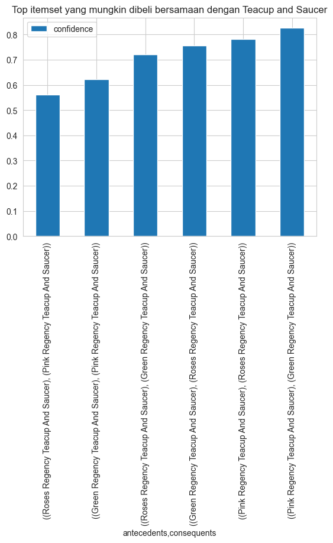

```python
# Melakukan visualisasi untuk melihat confidence itemset yang mungkin dibeli bersamaan dengan Teacup and Saucer
rulesapriori[rulesapriori["antecedents"].apply(lambda x: "Teacup And Saucer" in str(x))].groupby(
    ['antecedents', 'consequents'])[['confidence']].max().sort_values(ascending=False,
                                                                      by='confidence').head(10).plot(kind='bar').invert_xaxis()
plt.title('Top itemset yang mungkin dibeli bersamaan dengan Teacup and Saucer');
```

```python
rulesapriori['antecedents'] = rulesapriori.antecedents.apply(lambda x: next(iter(x)))
rulesapriori['consequents'] = rulesapriori.consequents.apply(lambda x: next(iter(x)))
```

```python
import plotly.graph_objs as go
from plotly.offline import init_notebook_mode, iplot

import networkx as nx
import warnings
warnings.filterwarnings('ignore')

init_notebook_mode(connected=True)

# Create a Plotly figure
fig = go.Figure()

edges = nx.from_pandas_edgelist(rules.sort_values(ascending=False,by='lift')
                           ,source='antecedents',target='consequents',edge_attr=None)
pos = nx.spring_layout(edges, seed=42)  # use spring_layout instead
# Add edges as scatter trace
edge_x = []
edge_y = []
for edge in edges.edges():
    x0, y0 = pos[edge[0]]
    x1, y1 = pos[edge[1]]
    edge_x.append(x0)
    edge_x.append(x1)
    edge_x.append(None)
    edge_y.append(y0)
    edge_y.append(y1)
    edge_y.append(None)

edge_trace = go.Scatter(
    x=edge_x, y=edge_y,
    line=dict(width=0.5, color='#888'),
    hoverinfo='none',
    mode='lines')

fig.add_trace(edge_trace)

# Add nodes as scatter trace
node_x = []
node_y = []
node_text = []
for node in edges.nodes():
    x, y = pos[node]
    node_x.append(x)
    node_y.append(y)
    node_text.append(node)

node_trace = go.Scatter(
    x=node_x, y=node_y,
    mode='markers',
    hoverinfo='text',
    marker=dict(
        showscale=False,
        colorscale='YlGnBu',
        reversescale=True,
        color=[],
        size=10,
        line_width=2))

node_trace.text = node_text
fig.add_trace(node_trace)

# Set layout and display the figure
fig.update_layout(
    title='Top 100 itemset in term of (lift)',
    title_font_size=25,
    font_size=18,
    showlegend=False,
    hovermode='closest',
    margin=dict(b=20,l=5,r=5,t=40),
    xaxis=dict(showgrid=False, zeroline=False, showticklabels=False),
    yaxis=dict(showgrid=False, zeroline=False, showticklabels=False))

iplot(fig)
```

[interactive chart not shown]

**Congratulations on completing the first part of this assignment!** 🎉🎉🎉